# Weapons and Hitpoints

In this chapter, we’ll add winning and losing conditions by implementing ship hitpoints.

We’ll see how to handle weapons firing and registering damage to the ships. We have to transfer weapon parameters across viewports for both projectiles and lasers. Since we already implemented most of the building blocks, we can see how easy it is to expand our previous work.

We’ll also add an attack label feedback animation when weapons interact with the ship rooms.

Check out this video to get an idea of how we’ll progress by the end of this lesson.

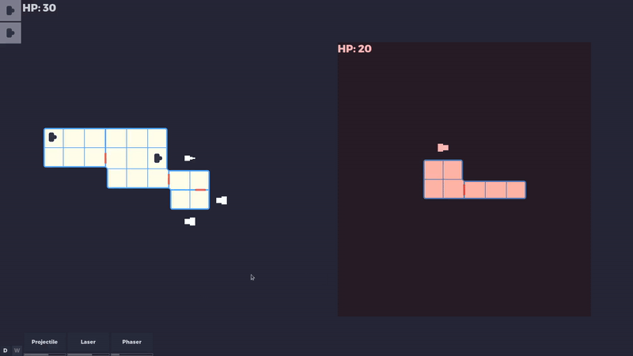

Before handling weapon interactions with the ships, we need a few extra scenes to show the winner of the game and add player feedback when ships take damage.

## The end scene

We start by creating an end scene that shows the winner of the match from the player’s perspective. We also include a couple of buttons for retrying or quitting the demo.

Here’s an example of how it looks if the player wins:

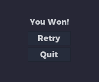

Open a new empty scene and pick a

[figure not shown]

`CenterContainer` node as root, then rename it to *End*. Continue by following this scene tree:

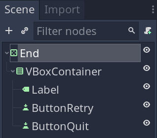

Select the *End* node and assign `res://TacticalSpaceCombat/Assets/Theme.tres` to the

[figure not shown]

`Theme` property to keep the looks consistent over different scenes.

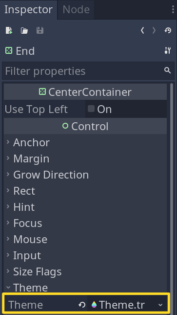

Select the

[figure not shown]

`Label` and assign `You Won!` to the *Text* field in the *Inspector* as a default placeholder. We update this in code as needed.

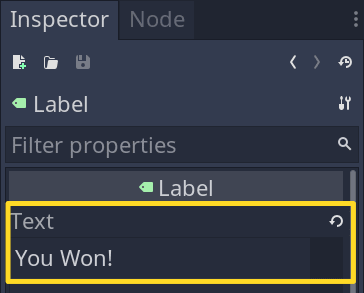

Wrap up by setting the *Text* property for the retry button to “Retry” and the quit button to "Quit. The last step is setting the *Right* and *Bottom* anchor properties for the center container to 1.0, making the window fill the screen.

Save the new scene file as `res://TacticalSpaceCombat/End.tscn`.

Add this script to the root node:

```
extends CenterContainer

const MAIN_SCENE := "res://TacticalSpaceCombat.tscn"

onready var label: Label = $VBoxContainer/Label
onready var button_retry: Button = $VBoxContainer/ButtonRetry
onready var button_quit: Button = $VBoxContainer/ButtonQuit


func _ready() -> void:
    button_retry.connect("pressed", get_tree(), "change_scene", [MAIN_SCENE])
    button_quit.connect("pressed", get_tree(), "quit")
    label.text = "You %s!" % ("Won" if Global.winner_is_player else "Lost")
```

It takes care of all the necessary actions - buttons changing the scene and quitting and updating the text label with the winner. But, at this point, we haven’t defined `Global.winner_is_player`.

It’s a minor fix, so let’s do it now. Open `res://Global.gd` and define the variable at the top:

```
# ...
# enum Layers { NONE }

var winner_is_player := false
```

And we have finished working on the end screen.

Let’s make a new scene for attack labels that we can use for player feedback when the ship takes damage.

## The attack labels

Create a new scene with a

[figure not shown]

`Control` node as root. Rename it to *AttackLabel*.

Reset its *Anchor* properties, so it doesn’t distract us. This will also update its *Rect -> Size* to `Vector2(0, 0)`.

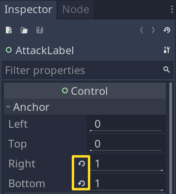

Continue by setting up the rest of the following scene tree:

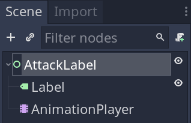

We need a rising animation for the

[figure not shown]

`Label`, as seen in the introduction video.

To create it, we use the

[figure not shown]

`AnimationPlayer` node.

First, let’s set up the default properties on the

[figure not shown]

`Label` node. Select it in the scene tree dock and assign `0` to its *Text* property as a placeholder value. We update it from code based on the attack values we’ll have on the weapons.

I also set *Align* to *Center* for other values that have different widths.

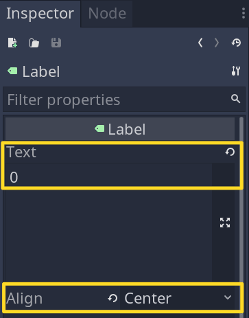

To keep it neat and centered at all times, we align the label with the origin and set *Grow Direction -> Horizontal* to *Both*:

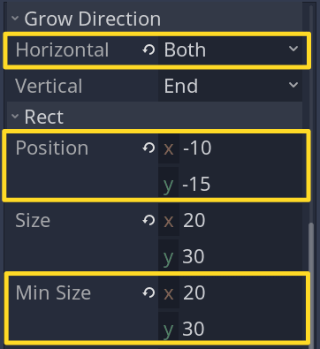

If you now change *Text* to something else, you’ll notice how the label grows in both directions horizontally while keeping the alignment with origin.

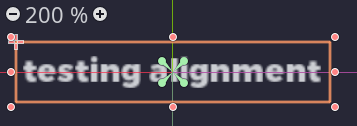

If you do a test like that, make sure to realign the

[figure not shown]

`Label`.

Continue with the rest of the properties:

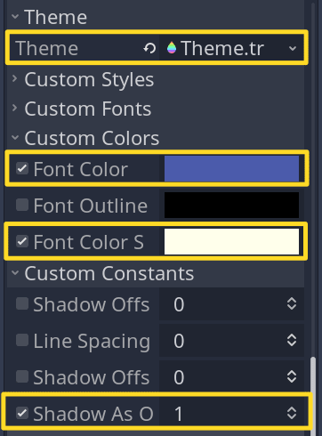

I’m using `#4b5bab` for *Font Color* and `#ffffeb` for *Font Color Shadow* to make the text pop.

I also switched on and set *Shadow As Outline* to `1` to outline the text instead of using the regular shadow.

We can now make a simple “bubble-up” animation. Before anything, though, we start by locking in the default values for the properties we want to animate.

Select the

[figure not shown]

`AnimationPlayer` node, and click on the

[figure not shown]

`Animation` tab in the bottom dock to open the animation workspace.

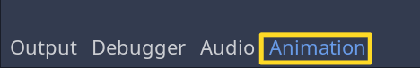

From there, click on the

[figure not shown]

`Animation` button and select *New* to make a new empty animation.

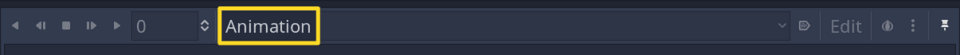

Name the animation `RESET`. This is our go-to name for the base animation that holds the default values.

Set the time value to `0` (it will default to `0.001`). Since this animation is for easy access to default values, we don’t need to give it any length of time.

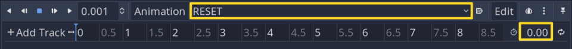

Now select the

[figure not shown]

`Label` and add a key for the default value of *Rect -> Position*. This is the only value we’ll be animating.

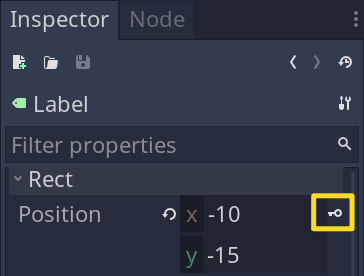

With that out of the way, make a new animation and name it `feedback`. Set its length to `0.6` seconds and add the default *Rect -> Position* at time `0` for

[figure not shown]

`Label`.

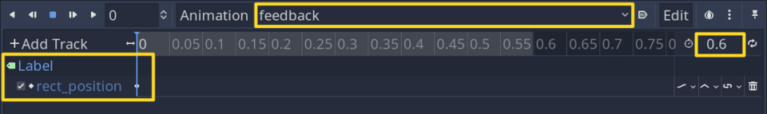

Select the key in the timeline and set its *Easing* to `2` in the *Inspector*. You can do this by `RMB` clicking on the curve and selecting *In*.

This will give it an acceleration as the play head advances. In animation terms, it’s called easing in.

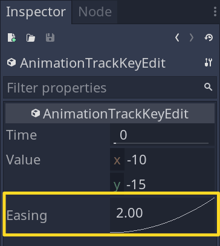

[figure not shown]

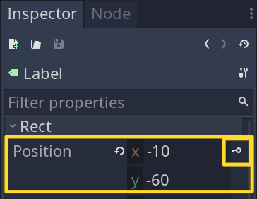

Your timeline should look like this:

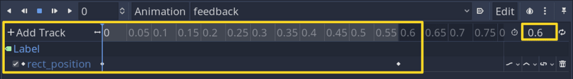

To finish off, we want the *AttackLabel* scene to remove itself from the scene tree after its animation finishes. To do this, we add a *Call Method Track* to our animation.

Click on the *Add Track* button and select *Call Method Track*.

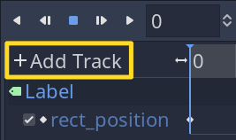

Pick *AttackLabel* from the pop-up menu and insert a `queue_free()` key at the end of the animation. You can insert the key by `RMB` clicking on the track’s timeline.

You should have this final animation:

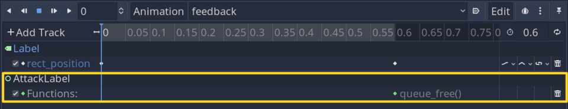

Save the scene at `res://TacticalSpaceCombat/Ship/Weapons/AttackLabel.tscn` if you haven’t done so yet.

To code the attack label add a script to the *AttackLabel* root node with the following content:

```
extends Control

onready var label: Label = $Label
onready var animation_player: AnimationPlayer = $AnimationPlayer

var _position := Vector2.ZERO
var _text := ""


func setup(attack: int, position: Vector2) -> void:
    _position = position
    _text = "%d" % attack


func _ready() -> void:
    rect_position = _position
    label.text = _text
    animation_player.play("feedback")
```

We’ll instantiate the *AttackLabel* from code when a successful hit lands on the ships. So for each hit, we need the attack value and a proper position. We use the `setup()` function for this.

And as soon as the *AttackLabel* is ready, we set the stored values and start the animation.

The animation finishes by calling `queue_free()`, which destroys the scene when it completes its job.

## UI hitpoints

We need to update the *TacticalSpaceCombat* scene to give player feedback for their remaining hitpoints.

Add these new nodes to the scene:

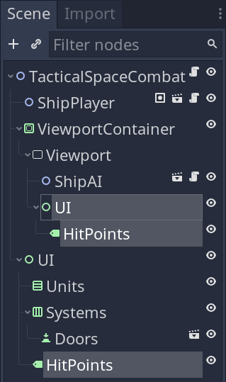

Set the *Text* property to `HP: 100` as a placeholder. You can do this on both labels simultaneously by selecting both of them in the scene dock.

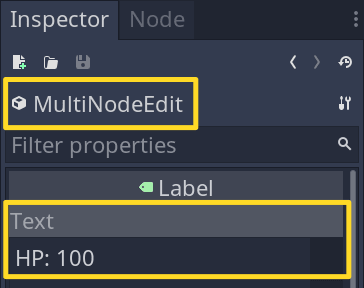

With both labels still selected, we assign the prepared bolder font, `res://TacticalSpaceCombat/Assets/Font/MontserratExtraBold24.tres`, to *Custom Fonts -> Font* property to make the text stand out a bit more.

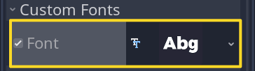

Set *Rect -> Position* to `Vector2(64, 0)` on *TacticalSpaceCombat -> UI -> HitPoints* so it doesn’t overlap with the *Units* UI.

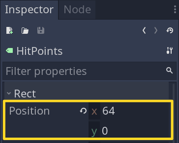

After completing the given steps, you should have the *HitPoints* labels placed like in the following example:

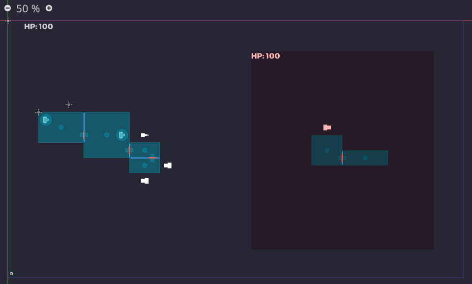

I tinted the AI viewport with pink, so it stands out from the rest of the scene.

## Handling weapon attacks

To affect ships’ hitpoints, we need to assign an attack value to each weapon. We start with updating the weapon scripts and then moving on to handling the interaction.

### Transfering weapon data over viewports

Open the `Weapon.gd` script and add a new `attack` variable at the top:

```
# ...
# export var charge_time := 2.0
export (int, 0, 5) var attack := 2
```

I limited the value range to (`0`, `5`) and set the default value to `2` as a middle ground.

We now need to send this information across viewports for both the projectile and the laser weapon, respectively.

Open the `WeaponProjectile.gd` script and replace `params`, in `fire()` with:

```
func fire() -> void:
    # ...
    # projectile.linear_velocity =
    # projectile.linear_velocity.rotated(global_rotation)
    var params := {
        "physics_layer": _physics_layer,
        "target_position": target_position,
        "attack": attack
    }
```

Do the same in `WeaponLaser.gd`:

```
func fire() -> void:
    # ...
    # line.visible = true
    var params := {"duration": timer.wait_time, "attack": attack}
```

We now send them across viewports, but we still need to store them somewhere before using them in `ShipTemplate.gd` to deal damage to the opposing ship’s hitpoints.

Open the `Projectile.gd` script and add a `params` declaration at the top:

```
# ...
# var max_distance := MAX_DISTANCE
var params := {}
```

We add `params` to the

[figure not shown]

`Area2D` node that interacts with the ship rooms for the laser weapon. To do this, open the *LaserTracker* scene file and assign a new script to the

[figure not shown]

`Area2D` node.

[figure not shown]

Save the script at `res://TacticalSpaceCombat/Ship/Weapons/LaserArea.gd` with this content:

```
extends Area2D

var params := {}
```

The script holds the `params` values until we use them in the `ShipTemplate.gd` script.

We declared the `params` variables, and now we need to assign values to them.

Open the `Projectiles.gd` script and add this line of code in `_on_Weapon_projectile_exited()`:

```
func _on_Weapon_projectile_exited(params: Dictionary) -> void:
    # ...
    # projectile.max_distance *= 2
    projectile.params = params
```

We do the same for the laser weapon. Open the `LaserTracker.gd` script and add this new lines of code in `_on_Weapon_fire_started()`:

```
func _on_Weapon_fire_started(params: Dictionary) -> void:
    # if Vector2.INF in target_line.points:
    #   return

    # We also set the `Area2D` node to `monitorable` whenever we fire the
    # weapon.
    area.set_deferred("monitorable", true)
    area.params = params
```

If you recall, we turned off *Monitorable* by default, so it doesn’t interact with the ship when the laser weapon isn’t firing.

Now we need to turn it back off at the end:

```
func _on_Weapon_fire_stopped() -> void:
    # ...
    # area.position = Vector2.ZERO
    area.set_deferred("monitorable", false)
```

This completes handling the transfer of weapon parameters from one viewport to the other.

### Handling the attacks

We start by setting the *Room -> HitArea2D* node to the proper physics layer to interact with the weapons from the other ship.

Open the `Room.gd` script and add a reference variable to the *HitArea2D* node:

```
# ...
# onready var sprite_target: Sprite = $SpriteTarget
onready var hit_area: Area2D = $HitArea2D
```

Then update its `collision_mask` property in the `setup()` function to the proper values depending on whether it’s the player ship or the AI ship.

```
func setup(tilemap: TileMap) -> void:
    # ...
    # _setup_extents()

    if not Engine.editor_hint:
        hit_area.collision_mask = (
            Global.Layers.SHIPPLAYER
            if owner.is_in_group("player")
            else Global.Layers.SHIPAI
        )
```

We’re now ready to handle the damage taken in the `ShipTemplate.gd` script. Open it then lets start by adding a signal at the top:

```
signal hitpoints_changed(hitpoints, is_player)
```

We use this signal to update the UI *Hitpoints* labels. Since we have one script for both player and AI, we distinguish between them with the second parameter: `is_player`.

Next, let’s preload the *AttackLabel* and add a hitpoints variable for the ships’ health.

```
# ...
# const LaserTracker := preload("Weapons/LaserTracker.tscn")
const AttackLabel := preload("Weapons/AttackLabel.tscn")

export (int, 0, 30) var hitpoints := 30
```

We now move on to handling the attacks via projectiles and lasers:

```
## Handles projectiles.
func _on_RoomHitArea2D_body_entered(body: RigidBody2D, room: Room) -> void:
    # We make sure that the projectiles interact with the correct `Room` by
    # checking their positions.
    if not room.position.is_equal_approx(body.params.target_position):
        return

    body.queue_free()
    _take_damage(body.params.attack, room.position)


## Handles lasers.
func _on_RoomArea2D_area_entered(area: Area2D, room: Room) -> void:
    if area.is_in_group("laser"):
        _take_damage(area.params.attack, room.position)
```

We need to implement a new function called `_take_damage()` that handles decreasing the `hitpoints` value and adding attack labels for player feedback:

```
func _take_damage(attack: int, object_position: Vector2) -> void:
    var attack_label := AttackLabel.instance()
    attack_label.setup(attack, object_position)
    add_child(attack_label)

    hitpoints -= attack
    hitpoints = max(0, hitpoints)
    emit_signal("hitpoints_changed", hitpoints, is_in_group("player"))
```

To finish off updating the `ShipTemplate.gd` script, we need to connect the proper signals to the `_on_Room*()` functions. We do this in `_ready_not_editor_hint()`:

```
func _ready_not_editor_hint() -> void:
    # ...
    # for room in rooms.get_children():
        room.connect("area_entered", self, "_on_RoomArea2D_area_entered", [room])
        room.hit_area.connect("body_entered", self, "_on_RoomHitArea2D_body_entered", [room])
```

Note that we send the extra `room` parameter to each function. That’s for adding the *AttackLabel* in proper positions when the weapons interact with specific rooms.

## Win conditions

The only thing left for us to do is update the UI *HitPoints* labels whenever the `hitpoints_changed` signal emits and switch the scene when one of the ships hits `0` hitpoints.

We do this in the main `TacticalSpaceCombat.gd` script. Open the file in the script editor, and let’s start by adding the path to the *End* scene so we can switch to it:

```
# ...
# const UIWeapon = preload("TacticalSpaceCombat/UI/UIWeapon.tscn")

const END_SCENE = "TacticalSpaceCombat/End.tscn"
```

We also need references to the new labels:

```
# ...
# onready var ui_systems: HBoxContainer = $UI/Systems
onready var ui_hitpoints_player: Label = $UI/HitPoints
onready var ui_hitpoints_ai: Label = $ViewportContainer/Viewport/UI/HitPoints
```

We connect the ships’ `hitpoints_changed` signal in the `_ready()` function:

```
func _ready() -> void:
    ship_player.connect("hitpoints_changed", self, "_on_Ship_hitpoints_changed")
    ship_ai.connect("hitpoints_changed", self, "_on_Ship_hitpoints_changed")
    # ui_doors.connect("pressed", ship_player, "_on_UIDoorsButton_pressed")
    # ...
    # _ready_weapons_player()

    # We finish off by manually calling the function to overwrite the default
    # `Label` text.
    _on_Ship_hitpoints_changed(ship_player.hitpoints, true)
    _on_Ship_hitpoints_changed(ship_ai.hitpoints, false)
```

Finally, we add the missing function to the script:

```
func _on_Ship_hitpoints_changed(hitpoints: int, is_player: bool) -> void:
    var label := ui_hitpoints_player if is_player else ui_hitpoints_ai
    label.text = "HP: %d" % hitpoints
    if hitpoints == 0:
        Global.winner_is_player = not is_player
        get_tree().change_scene(END_SCENE)
```

## Testing the demo

When testing the demo, I invite you to play with the different weapon and ship properties. In my case, I set the *ShipAI Hitpoints* value to `20` and left *ShipPlayer* to the default value.

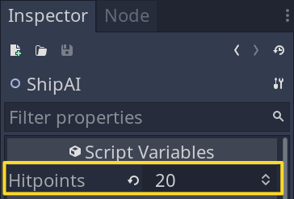

You should now be able to play the demo and reach either a win or lose condition.

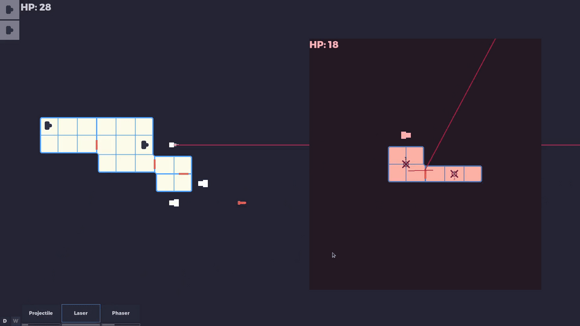

## Conclusion

In this lesson, we hit a new milestone by handling weapon attacks. We now have win-or-lose states.

In implementing these, we saw how to transfer information from one viewport to another via signals when firing the weapons.

We also saw how to handle updating our UI when the ship’s hitpoints change when attacked.

We also saw how to use the

[figure not shown]

`AnimationPlayer` for more than pure animations efficiently. We made a self-contained attack label that cleans itself up by calling `queue_free()` at the end of the animation.

We saw how to align labels, so they grow evenly to keep things neat and centered.

Finally, we saw how to persist data across scenes using our custom `Global` singleton to update the winner information.

In the following lessons, we’ll go over optional shields for the ships and how they interact with the weapons.

## Code reference

`res://TacticalSpaceCombat/End.gd`:

```
extends CenterContainer

const MAIN_SCENE := "res://TacticalSpaceCombat.tscn"

onready var label: Label = $VBoxContainer/Label
onready var button_retry: Button = $VBoxContainer/ButtonRetry
onready var button_quit: Button = $VBoxContainer/ButtonQuit


func _ready() -> void:
    button_retry.connect("pressed", get_tree(), "change_scene", [MAIN_SCENE])
    button_quit.connect("pressed", get_tree(), "quit")
    label.text = "You %s!" % ("Won" if Global.winner_is_player else "Lost")
```

`res://Global.gd`:

```
extends Node

enum Layers { NONE }

var winner_is_player := false


func _ready() -> void:
    var label := 'layer_names/2d_physics/layer_%d'
    for i in range(20):
        var layer_name: String = ProjectSettings.get_setting(label % (i + 1))
        if layer_name != '':
            Layers[layer_name.to_upper()] = 1 << i
```

`res://TacticalSpaceCombat/Ship/Weapons/AttackLabel.gd`:

```
extends Control

onready var label: Label = $Label
onready var animation_player: AnimationPlayer = $AnimationPlayer

var _position := Vector2.ZERO
var _text := ""


func setup(attack: int, position: Vector2) -> void:
    _position = position
    _text = "%d" % attack


func _ready() -> void:
    rect_position = _position
    label.text = _text
    animation_player.play("feedback")
```

`res://TacticalSpaceCombat/Ship/Weapons/Weapon.gd`:

```
class_name Weapon
extends Sprite

const MIN_CHARGE := 0
const MAX_CHARGE := 100

export var weapon_name := ""
export var charge_time := 2.0
export (int, 0, 5) var attack := 2

var is_charging := false setget set_is_charging

var _charge := MIN_CHARGE

onready var tween: Tween = $Tween


func _ready() -> void:
    tween.connect("tween_all_completed", self, "set_is_charging", [false])
    self.is_charging = true


func fire() -> void:
    pass


func set_is_charging(value: bool) -> void:
    is_charging = value
    if is_charging:
        tween.interpolate_property(self, "_charge", MIN_CHARGE, MAX_CHARGE, charge_time)
        tween.start()
    fire()
```

`res://TacticalSpaceCombat/Ship/Weapons/WeaponProjectile.gd`:

```
tool
extends Weapon

signal fired
signal projectile_exited(params)

const Projectile := preload("Projectile.tscn")

var target_position := Vector2.INF

var _physics_layer := -1


func setup(physics_layer: int) -> void:
    _physics_layer = physics_layer


func _get_configuration_warning() -> String:
    var parent := get_parent()
    var is_verified := parent != null and parent is ControllerAIProjectile or parent is ControllerPlayerProjectile
    return "" if is_verified else "WeaponProjectile needs to be a parent of Controller*Projectile"


func fire() -> void:
    if not can_fire():
        return

    self.is_charging = true
    var projectile: RigidBody2D = Projectile.instance()
    projectile.linear_velocity = projectile.linear_velocity.rotated(global_rotation)
    var params := {
        "physics_layer": _physics_layer,
        "target_position": target_position,
        "attack": attack
    }
    projectile.connect("tree_exited", self, "emit_signal", ["projectile_exited", params])
    add_child(projectile)
    emit_signal("fired")


func can_fire() -> bool:
    return not is_charging and target_position != Vector2.INF
```

`res://TacticalSpaceCombat/Ship/Weapons/WeaponLaser.gd`:

```
tool
extends Weapon

signal fire_started(params)
signal fire_stopped

export (int, 0, 250) var targeting_length := 140
export var color := Color("b0305c")

var has_targeted := false

onready var timer: Timer = $Timer
onready var line: Line2D = $Line2D


func _ready() -> void:
    if Engine.editor_hint:
        return

    timer.connect("timeout", self, "emit_signal", ["fire_stopped"])
    timer.connect("timeout", self, "set_is_charging", [true])
    timer.connect("timeout", line, "set_visible", [false])
    line.default_color = color


func _get_configuration_warning() -> String:
    var parent := get_parent()
    var is_verified := parent != null and parent is ControllerAILaser or parent is ControllerPlayerLaser
    return "" if is_verified else "WeaponLaser needs to be a parent of Controller*Laser"


func fire() -> void:
    if not can_fire():
        return

    timer.start()
    has_targeted = false
    line.visible = true
    var params := {"duration": timer.wait_time, "attack": attack}
    emit_signal("fire_started", params)


func can_fire() -> bool:
    return not is_charging and has_targeted
```

`res://TacticalSpaceCombat/Ship/Weapons/LaserArea.gd`:

```
extends Area2D

var params := {}
```

`res://TacticalSpaceCombat/Ship/Projectiles.gd`:

```
extends Node2D

const Projectile = preload("Weapons/Projectile.tscn")

var _rng := RandomNumberGenerator.new()
var _mean_position := Vector2.INF


func setup(mean_position: Vector2) -> void:
    _mean_position = mean_position


func _ready() -> void:
    _rng.randomize()


func _on_Weapon_projectile_exited(params: Dictionary) -> void:
    var projectile: RigidBody2D = Projectile.instance()
    var spawn_position := _mean_position + Utils.randvf_circle(_rng, projectile.MAX_DISTANCE)
    var direction: Vector2 = (params.target_position - spawn_position).normalized()
    projectile.collision_layer = params.physics_layer
    projectile.position = spawn_position
    projectile.linear_velocity = direction * projectile.linear_velocity.length()
    projectile.rotation = direction.angle()
    projectile.max_distance *= 2
    projectile.params = params
    add_child(projectile)
```

`res://TacticalSpaceCombat/Ship/Weapons/LaserTracker.gd`:

```
extends Node2D

signal targeted(msg)

const LINE_DEFAULT := PoolVector2Array([Vector2.INF, Vector2.INF])

var _is_targeting := false
var _targeting_length := 0
var _rng := RandomNumberGenerator.new()
var _rooms: Node2D = null

onready var tween: Tween = $Tween
onready var area: Area2D = $Area2D
onready var line: Line2D = $Line2D
onready var target_line: Line2D = $TargetLine2D


func setup(color: Color, rooms: Node2D) -> void:
    _rooms = rooms
    line.default_color = color
    target_line.default_color = color


func _ready() -> void:
    _rng.randomize()
    target_line.points = LINE_DEFAULT
    line.points = LINE_DEFAULT


func _unhandled_input(event: InputEvent) -> void:
    if not (event is InputEventMouse and _is_targeting):
        return

    if event.is_action_pressed("left_click"):
        target_line.points[0] = get_local_mouse_position()
    elif target_line.points[0] != Vector2.INF and event is InputEventMouseMotion:
        var offset: Vector2 = get_local_mouse_position() - target_line.points[0]
        offset = offset.clamped(_targeting_length)
        target_line.points[1] = target_line.points[0] + offset
    elif event.is_action_released("left_click") and target_line.points[1] != Vector2.INF:
        _is_targeting = false
        emit_signal("targeted", {"type": Controller.Type.LASER})


func _on_Controller_targeting(msg: Dictionary) -> void:
    match msg:
        {"targeting_length": var targeting_length, "is_targeting": var is_targeting}:
            _is_targeting = is_targeting
            _targeting_length = targeting_length
            if _is_targeting:
                target_line.points = LINE_DEFAULT
        {"targeting_length": var targeting_length}:
            target_line.points = _rooms.get_laser_points(targeting_length)
            emit_signal("targeted", {"type": Controller.Type.LASER})


func _on_Weapon_fire_started(params: Dictionary) -> void:
    if Vector2.INF in target_line.points:
        return

    area.set_deferred("monitorable", true)
    area.params = params

    line.points[0] = _rooms.mean_position + Utils.randvf_circle(_rng, Projectile.MAX_DISTANCE)
    tween.interpolate_method(
        self, "_swipe_laser", target_line.points[0], target_line.points[1], params.duration
    )
    tween.start()


func _on_Weapon_fire_stopped() -> void:
    tween.remove_all()
    target_line.points = LINE_DEFAULT
    line.points = LINE_DEFAULT
    area.position = Vector2.ZERO
    area.set_deferred("monitorable", false)


func _swipe_laser(offset: Vector2) -> void:
    line.points[1] = offset
    area.position = line.points[1]
```

`res://TacticalSpaceCombat/Ship/Rooms/Room.gd`:

```
tool
class_name Room
extends Area2D

signal targeted(msg)

export var size := Vector2.ONE setget set_size

var _target_index := -1

var _rng := RandomNumberGenerator.new()
var _entrances := {}
var _area := 0
var _top_left := Vector2.ZERO
var _bottom_right := Vector2.ZERO

var _iter_index := 0

var _tilemap: TileMap = null

onready var collision_shape: CollisionShape2D = $CollisionShape2D
onready var feedback: NinePatchRect = $Feedback
onready var sprite_target: Sprite = $SpriteTarget
onready var hit_area: Area2D = $HitArea2D


func setup(tilemap: TileMap) -> void:
    _tilemap = tilemap
    _setup_extents()

    if not Engine.editor_hint:
        hit_area.collision_mask = (
            Global.Layers.SHIPPLAYER
            if owner.is_in_group("player")
            else Global.Layers.SHIPAI
        )

    _area = size.x * size.y
    _top_left = _tilemap.world_to_map(position - collision_shape.shape.extents)
    _bottom_right = _top_left + size

    feedback.rect_position -= collision_shape.shape.extents
    feedback.rect_size = 2 * collision_shape.shape.extents


func _setup_extents() -> void:
    if _tilemap != null:
        collision_shape.shape.extents = 0.5 * _tilemap.map_to_world(size)


func _ready() -> void:
    connect("mouse_entered", self, "_on_mouse_entered_exited", [true])
    connect("mouse_exited", self, "_on_mouse_entered_exited", [false])
    connect("area_entered", self, "_on_area_entered")
    connect("input_event", self, "_on_input_event")
    _rng.randomize()


func _on_input_event(_v: Viewport, event: InputEvent, _s: int) -> void:
    if (
        event.is_action_pressed("left_click")
        and Input.get_current_cursor_shape() == Input.CURSOR_CROSS
        and _target_index != -1
    ):
        sprite_target.visible = true
        sprite_target.get_child(_target_index).visible = true
        emit_signal(
            "targeted",
            {
                "type": Controller.Type.PROJECTILE,
                "index": _target_index,
                "target_position": position
            }
        )
        _target_index = -1


func _on_mouse_entered_exited(has_entered: bool) -> void:
    feedback.visible = has_entered
    var group := "selected-room"
    if has_entered:
        add_to_group(group)
    elif is_in_group(group):
        remove_from_group(group)


func _on_area_entered(area: Area2D) -> void:
    if area.is_in_group("door"):
        var entrance := position - area.position
        entrance = entrance.project(Vector2.DOWN.rotated(area.rotation)).normalized()
        entrance *= 0.5 * _tilemap.cell_size.x
        entrance += area.position
        entrance = _tilemap.world_to_map(entrance)
        _entrances[entrance] = null


func _on_Controller_targeting(msg: Dictionary) -> void:
    _target_index = msg.index
    if _target_index != -1:
        sprite_target.visible = false
        sprite_target.get_child(_target_index).visible = false
        for node in sprite_target.get_children():
            if node.visible:
                sprite_target.visible = true
                break


func randv() -> Vector2:
    var top_left_world := _tilemap.map_to_world(_top_left)
    var bottom_right_world := _tilemap.map_to_world(_bottom_right)
    return Utils.randvf_range(_rng, top_left_world, bottom_right_world)


func has_point(point: Vector2) -> bool:
    return Rect2(_top_left, size).has_point(point)


func set_size(value: Vector2) -> void:
    for axis in [Vector2.AXIS_X, Vector2.AXIS_Y]:
        size[axis] = max(1, value[axis])
    _setup_extents()


func get_slot(slots: Dictionary, unit: Unit) -> Vector2:
    var out := Vector2.INF
    var entrance := _get_entrance(_tilemap.world_to_map(unit.path_follow.position))

    var valid_positions := []
    for offset in self:
        valid_positions.push_back([offset, offset.distance_to(entrance)])
    valid_positions.sort_custom(self, "sort_by_second_index")

    for data in valid_positions:
        var offset: Vector2 = data[0]
        if not (offset in slots and slots[offset] != unit):
            out = offset
            break
    return out


static func sort_by_second_index(a: Array, b: Array) -> bool:
    return a[1] < b[1]


func _get_entrance(from: Vector2) -> Vector2:
    var out := Vector2.INF
    var distance := INF
    for entrance in _entrances:
        var curve: Curve2D = _tilemap.find_path(from, entrance)
        var length := curve.get_baked_length()
        if distance > length:
            distance = length
            out = entrance
    return out


func _iter_init(_arg) -> bool:
    _iter_index = 0
    return _iter_is_running()


func _iter_next(_arg) -> bool:
    _iter_index += 1
    return _iter_is_running()


func _iter_get(_arg) -> Vector2:
    var offset := Utils.index_to_xy(size.x, _iter_index)
    return _top_left + offset


func _iter_is_running() -> bool:
    return _iter_index < _area
```

`res://TacticalSpaceCombat/Ship/ShipTemplate.gd`:

```
tool
extends Node2D

signal hitpoints_changed(hitpoints, is_player)

const LaserTracker := preload("Weapons/LaserTracker.tscn")
const AttackLabel := preload("Weapons/AttackLabel.tscn")

export (int, 0, 30) var hitpoints := 30

var _slots := {}

onready var tilemap: TileMap = $TileMap
onready var rooms: Node2D = $Rooms
onready var doors: Node2D = $Doors
onready var units: Node2D = $Units
onready var weapons: Node2D = $Weapons
onready var projectiles: Node2D = $Projectiles
onready var lasers: Node2D = $Lasers


func _ready() -> void:
    call("_ready_editor_hint" if Engine.editor_hint else "_ready_not_editor_hint")


func _ready_editor_hint() -> void:
    for room in rooms.get_children():
        room.setup(tilemap)


func _ready_not_editor_hint() -> void:
    for unit in units.get_children():
        for door in doors.get_children():
            door.connect("opened", unit, "set_is_walking", [true])

        var position_map := tilemap.world_to_map(unit.path_follow.position)
        _slots[position_map] = unit

    for room in rooms.get_children():
        room.connect("area_entered", self, "_on_RoomArea2D_area_entered", [room])
        room.hit_area.connect("body_entered", self, "_on_RoomHitArea2D_body_entered", [room])
        room.setup(tilemap)

        for point in room:
            tilemap.set_cellv(point, 0)

    tilemap.setup(rooms, doors)
    projectiles.setup(rooms.mean_position)


func _get_configuration_warning() -> String:
    var is_verified := (
        is_in_group("player")
        and weapons.get_child_count() <= 4
        or not is_in_group("player")
    )
    return "" if is_verified else "%s can't have more than 4 weapons!" % name


func _unhandled_input(event: InputEvent) -> void:
    if not event.is_action_pressed("right_click"):
        return

    for unit in get_tree().get_nodes_in_group("selected-unit"):
        var point1: Vector2 = tilemap.world_to_map(unit.path_follow.position)
        for room in get_tree().get_nodes_in_group("selected-room"):
            if not room.owner.is_in_group("player"):
                break

            var point2: Vector2 = room.get_slot(_slots, unit)
            if is_inf(point2.x):
                break

            var path: Curve2D = tilemap.find_path(point1, point2)
            Utils.erase_value(_slots, unit)
            _slots[point2] = unit
            unit.walk(path)


func _on_UIDoorsButton_pressed() -> void:
    var has_opened_doors := false
    for door in doors.get_children():
        if door.is_open:
            has_opened_doors = true
            break

    for door in doors.get_children():
        door.is_open = not has_opened_doors


func _on_RoomHitArea2D_body_entered(body: RigidBody2D, room: Room) -> void:
    if not room.position.is_equal_approx(body.params.target_position):
        return

    body.queue_free()
    _take_damage(body.params.attack, room.position)


func _on_RoomArea2D_area_entered(area: Area2D, room: Room) -> void:
    if area.is_in_group("laser"):
        _take_damage(area.params.attack, room.position)


func add_laser_tracker(color: Color) -> Node:
    var laser_tracker := LaserTracker.instance()
    lasers.add_child(laser_tracker)
    laser_tracker.setup(color, rooms)
    return laser_tracker


func _take_damage(attack: int, object_position: Vector2) -> void:
    var attack_label := AttackLabel.instance()
    attack_label.setup(attack, object_position)
    add_child(attack_label)

    hitpoints -= attack
    hitpoints = max(0, hitpoints)
    emit_signal("hitpoints_changed", hitpoints, is_in_group("player"))
```

`res://TacticalSpaceCombat.gd`:

```
extends Node2D

const UIUnit = preload("TacticalSpaceCombat/UI/UIUnit.tscn")
const UIWeapons = preload("TacticalSpaceCombat/UI/UIWeapons.tscn")
const UIWeapon = preload("TacticalSpaceCombat/UI/UIWeapon.tscn")

const END_SCENE = "TacticalSpaceCombat/End.tscn"

onready var ship_player: Node2D = $ShipPlayer
onready var ship_ai: Node2D = $ViewportContainer/Viewport/ShipAI
onready var ui_units: VBoxContainer = $UI/Units
onready var ui_doors: Button = $UI/Systems/Doors
onready var ui_systems: HBoxContainer = $UI/Systems
onready var ui_hitpoints_player: Label = $UI/HitPoints
onready var ui_hitpoints_ai: Label = $ViewportContainer/Viewport/UI/HitPoints


func _ready() -> void:
    ship_player.connect("hitpoints_changed", self, "_on_Ship_hitpoints_changed")
    ship_ai.connect("hitpoints_changed", self, "_on_Ship_hitpoints_changed")
    ui_doors.connect("pressed", ship_player, "_on_UIDoorsButton_pressed")

    _ready_units()
    _ready_weapons_ai()
    _ready_weapons_player()

    _on_Ship_hitpoints_changed(ship_player.hitpoints, true)
    _on_Ship_hitpoints_changed(ship_ai.hitpoints, false)


func _ready_units() -> void:
    for unit in ship_player.units.get_children():
        var ui_unit: ColorRect = UIUnit.instance()
        ui_units.add_child(ui_unit)
        unit.setup(ui_unit)


func _ready_weapons_ai() -> void:
    for controller in ship_ai.weapons.get_children():
        if controller is ControllerAIProjectile:
            controller.connect("targeting", ship_player.rooms, "_on_Controller_targeting")
            controller.weapon.connect(
                "projectile_exited", ship_player.projectiles, "_on_Weapon_projectile_exited"
            )
            ship_player.rooms.connect("targeted", controller, "_on_Ship_targeted")
        elif controller is ControllerAILaser:
            var laser_tracker: Node = ship_player.add_laser_tracker(controller.weapon.color)
            controller.connect(
                "targeting", laser_tracker, "_on_Controller_targeting", [], CONNECT_DEFERRED
            )
            controller.weapon.connect("fire_started", laser_tracker, "_on_Weapon_fire_started")
            controller.weapon.connect("fire_stopped", laser_tracker, "_on_Weapon_fire_stopped")
            laser_tracker.connect("targeted", controller, "_on_Ship_targeted")


func _ready_weapons_player() -> void:
    for controller in ship_player.weapons.get_children():
        if not ui_systems.has_node("Weapons"):
            ui_systems.add_child(UIWeapons.instance())
        var ui_weapon: VBoxContainer = UIWeapon.instance()
        ui_systems.get_node("Weapons").add_child(ui_weapon)

        if controller is ControllerPlayerProjectile:
            controller.weapon.connect(
                "projectile_exited", ship_ai.projectiles, "_on_Weapon_projectile_exited"
            )
            for room in ship_ai.rooms.get_children():
                controller.connect("targeting", room, "_on_Controller_targeting")
                room.connect("targeted", controller, "_on_Ship_targeted")

        elif controller is ControllerPlayerLaser:
            var laser_tracker: Node = ship_ai.add_laser_tracker(controller.weapon.color)
            controller.connect(
                "targeting", laser_tracker, "_on_Controller_targeting", [], CONNECT_DEFERRED
            )
            controller.weapon.connect("fire_started", laser_tracker, "_on_Weapon_fire_started")
            controller.weapon.connect("fire_stopped", laser_tracker, "_on_Weapon_fire_stopped")
            laser_tracker.connect("targeted", controller, "_on_Ship_targeted")
        controller.setup(ui_weapon)


func _on_Ship_hitpoints_changed(hitpoints: int, is_player: bool) -> void:
    var label := ui_hitpoints_player if is_player else ui_hitpoints_ai
    label.text = "HP: %d" % hitpoints
    if hitpoints == 0:
        Global.winner_is_player = not is_player
        get_tree().change_scene(END_SCENE)
```